# 2016 Presidential Campaign Finance by Satyendra Gurjar

- This reports explores 2016 Presidential Campaign Finance dataset.
- We have used dataset of Connecticut state, downloaded from ftp://ftp.fec.gov/FEC/Presidential_Map/2016/P00000001/P00000001-CT.zip

```
## [1] 58172     9
```

```
## 'data.frame':    58172 obs. of  9 variables:
##  $ contbr_zip                      : chr  "06001" "06001" "06001" "06001" ...
##  $ cand_nm_last                    : Factor w/ 23 levels "Bush","Carson",..: 5 4 18 18 18 4 4 4 17 18 ...
##  $ cand_party                      : Factor w/ 4 levels "D","G","L","R": 4 1 1 1 1 1 1 1 4 1 ...
##  $ contb_receipt_amt               : num  250 506 30 100 20 19 30 25 100 50 ...
##  $ contb_receipt_dt                : Date, format: "2016-03-03" "2016-02-02" ...
##  $ median_household_income         : num  115745 115745 115745 115745 115745 ...
##  $ median_contb_amt                : num  30 30 30 30 30 30 30 30 30 30 ...
##  $ median_contb_amt_by_cand_party  : num  50 27 27 27 27 27 27 27 50 27 ...
##  $ median_contb_amt_by_cand_nm_last: num  50 94 27 27 27 94 94 94 100 27 ...
```

```
##   contbr_zip         cand_nm_last   cand_party contb_receipt_amt
##  Length:58172       Sanders:31463   D:49006    Min.   :    0.19
##  Class :character   Clinton:17461   G:   37    1st Qu.:   15.00
##  Mode  :character   Cruz   : 3376   L:   31    Median :   27.00
##                     Carson : 1771   R: 9098    Mean   :  157.56
##                     Rubio  : 1163              3rd Qu.:   75.00
##                     Bush   :  663              Max.   :10800.00
##                     (Other): 2275
##  contb_receipt_dt     median_household_income median_contb_amt
##  Min.   :2014-09-22   Min.   : 11413          Min.   :   5.00
##  1st Qu.:2016-01-29   1st Qu.: 67222          1st Qu.:  25.00
##  Median :2016-03-17   Median : 84131          Median :  27.00
##  Mean   :2016-02-28   Mean   : 91506          Mean   :  35.59
##  3rd Qu.:2016-04-29   3rd Qu.:107838          3rd Qu.:  38.61
##  Max.   :2016-06-30   Max.   :208078          Max.   :1850.00
##                       NA's   :22
##  median_contb_amt_by_cand_party median_contb_amt_by_cand_nm_last
##  Min.   :   5.00                Min.   :   3.00
##  1st Qu.:  25.00                1st Qu.:  25.00
##  Median :  27.00                Median :  27.00
##  Mean   :  51.58                Mean   :  82.74
##  3rd Qu.:  40.00                3rd Qu.:  50.00
##  Max.   :2700.00                Max.   :2700.00
##
```

- Dataset contains 9 variables with about 58000 observations.

# Univariate Plots Section

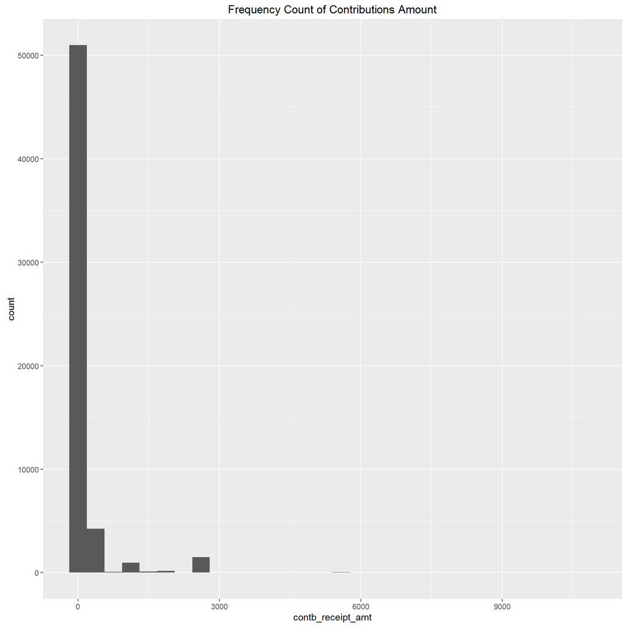

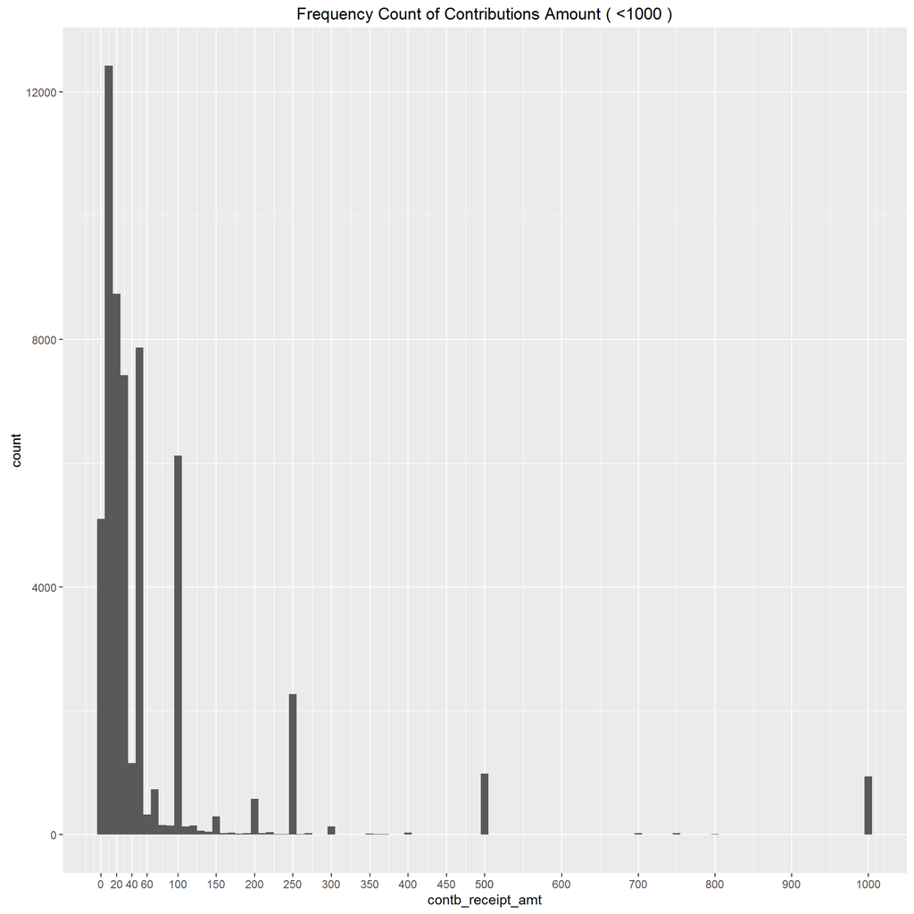

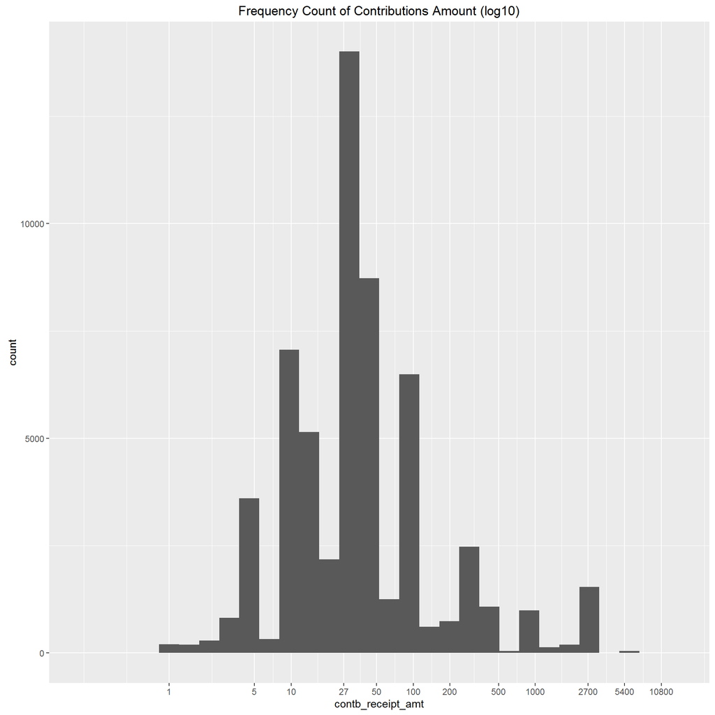

- After transforming contribution amount, it appears to be in normal distribution.

### Median Household Income

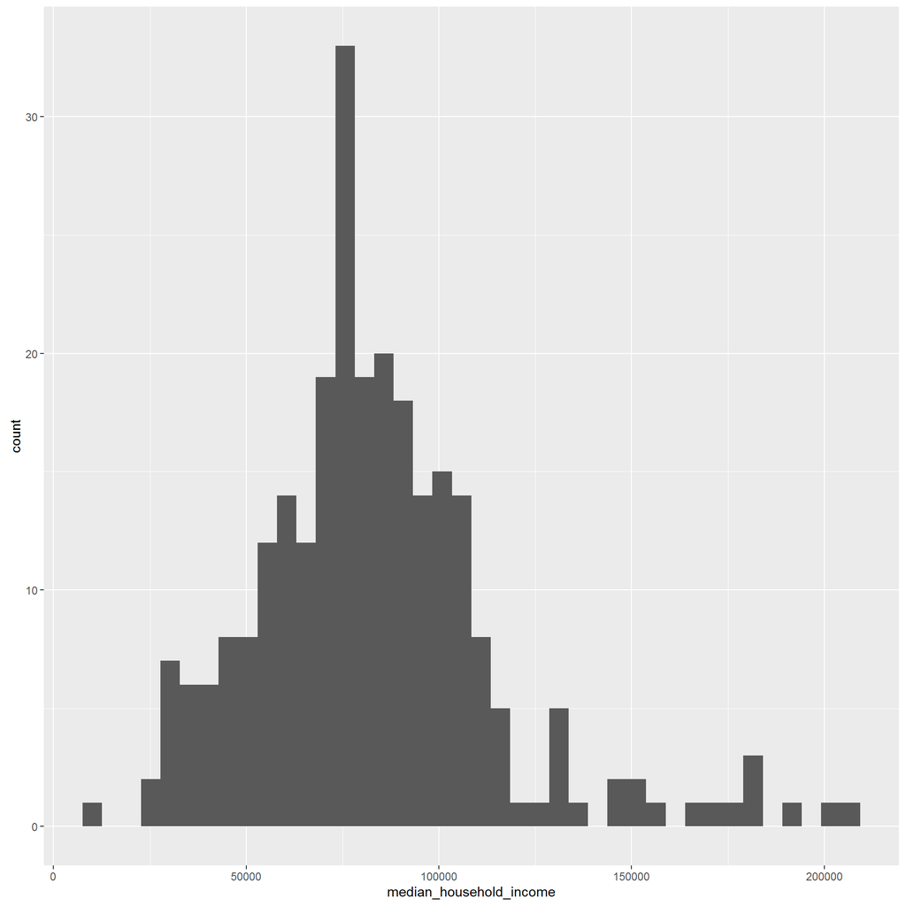

```
##    Min. 1st Qu.  Median    Mean 3rd Qu.    Max.
##   11410   64220   78880   82710   97400  208100
```

- Median Household income is normally distributed with mean `82710` and median `78880`.
- We should try to see if there is any relationship between median contribution amount for a zipcode and its median household income.

### Median Contribution Amount

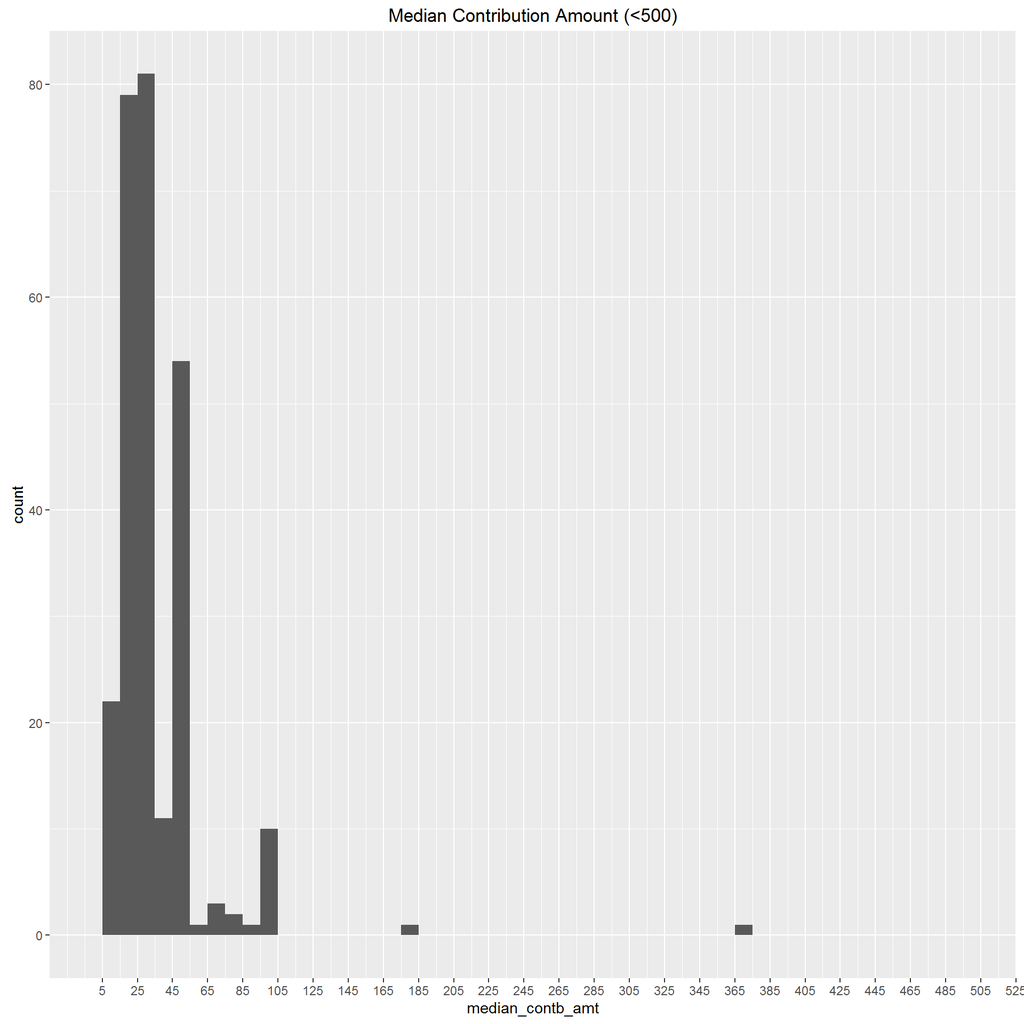

- Median Contribution Amount around `25` has most frequency and then around `50`.

# Univariate Analysis

### What is/are the main feature(s) of interest in your dataset?

- The main features is `median_household_income`.
- We will try to find relationship between contribution amount (`contb_receipt_amt`) and `median_household_income`.

### What other features in the dataset do you think will help support your investigation into your feature(s) of interest?

- `cand_nm_last` and `cand_party` likely to contribute to the `contb_receipt_amt`.

### Did you create any new variables from existing variables in the dataset?

- I created a variable `median_contb_amt`, which median contribution amount for a zipcode. As I expect it to be related to `median_household_income`.
- I also created `median_contb_amt` per zipcode by `cand_nm_last` and `cand_party`, `median_contb_amt_by_cand_nm_last` and `median_contb_amt_by_cand_party` respectively.

### Of the features you investigated, were there any unusual distributions? Did you perform any operations on the data to tidy, adjust, or change the form of the data? If so, why did you do this?

- I log-transformed the right skewed `contb_receipt_amt`. The transformed distribution for `contb_receipt_amt` appears to be normal.

# Bivariate Plots Section

## Contribution by candidates

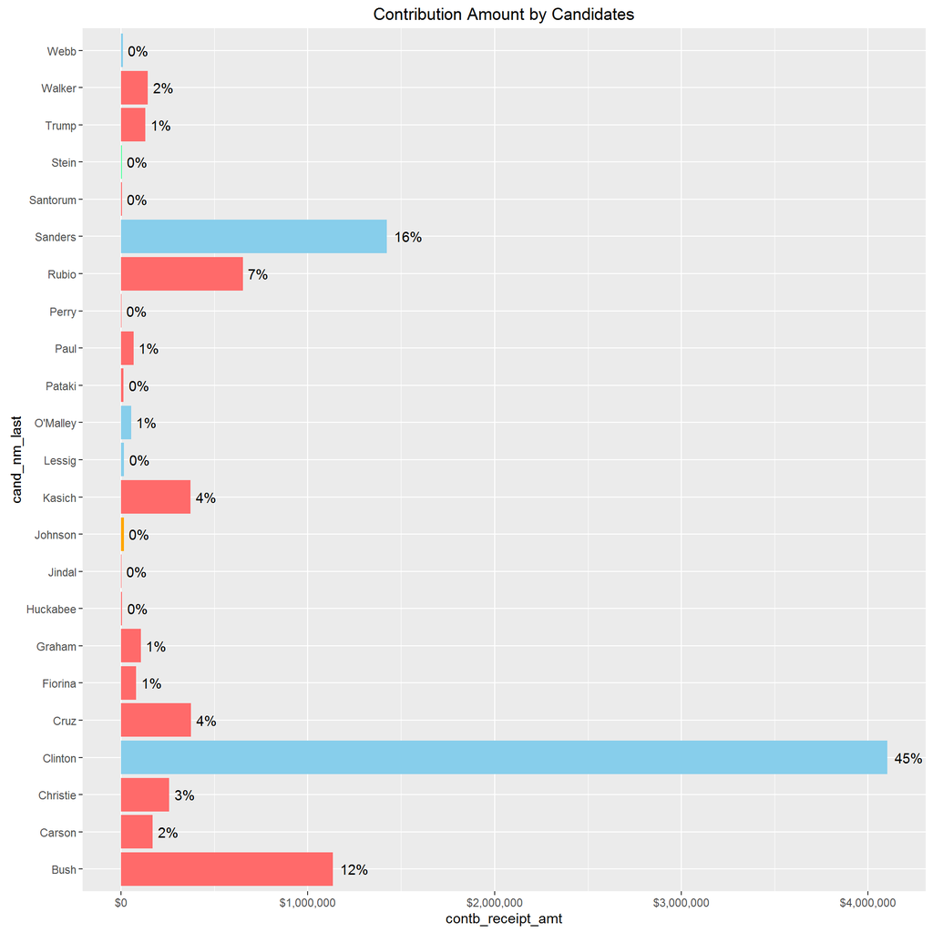

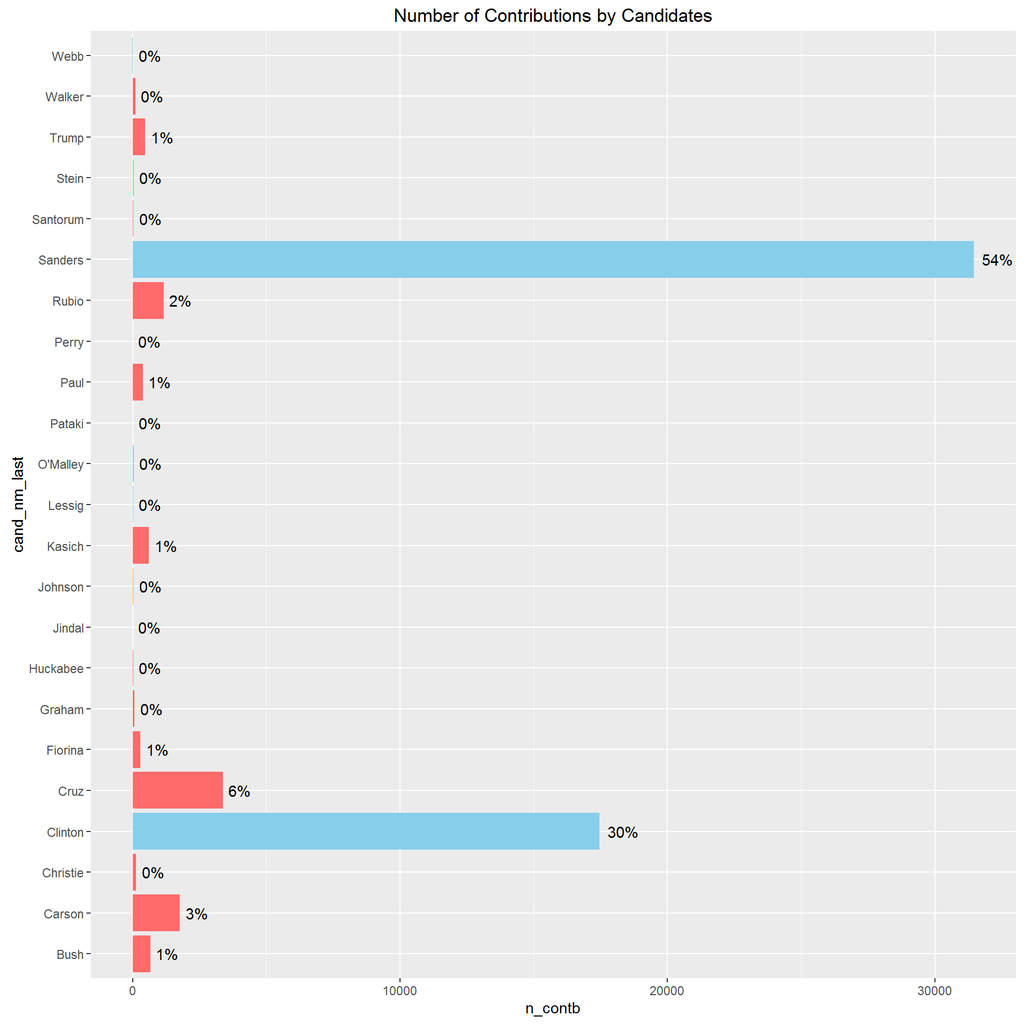

- Clinton received `45%` of contribution amount with `30%` of contributions.
- Sanders received `16%` of contribution amount with `54%` of contributions.

## Contribution by Party

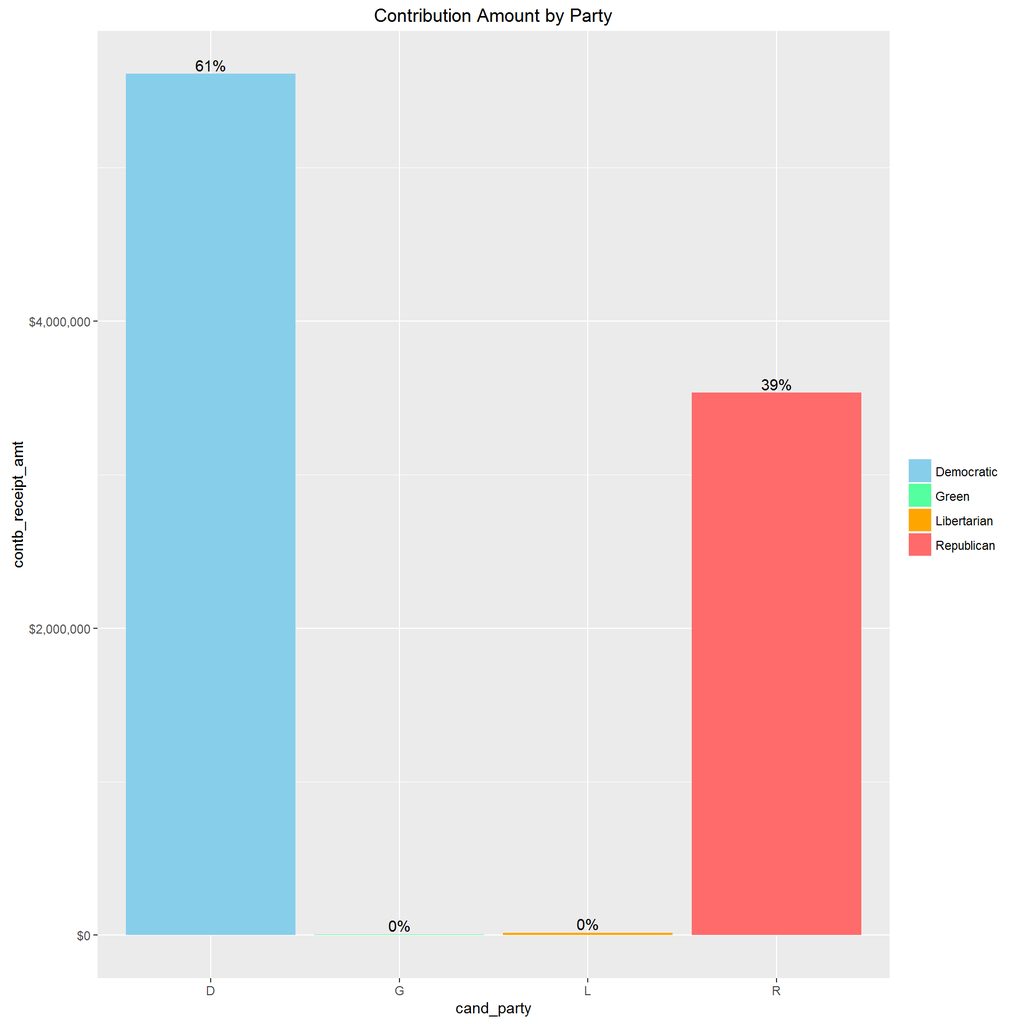

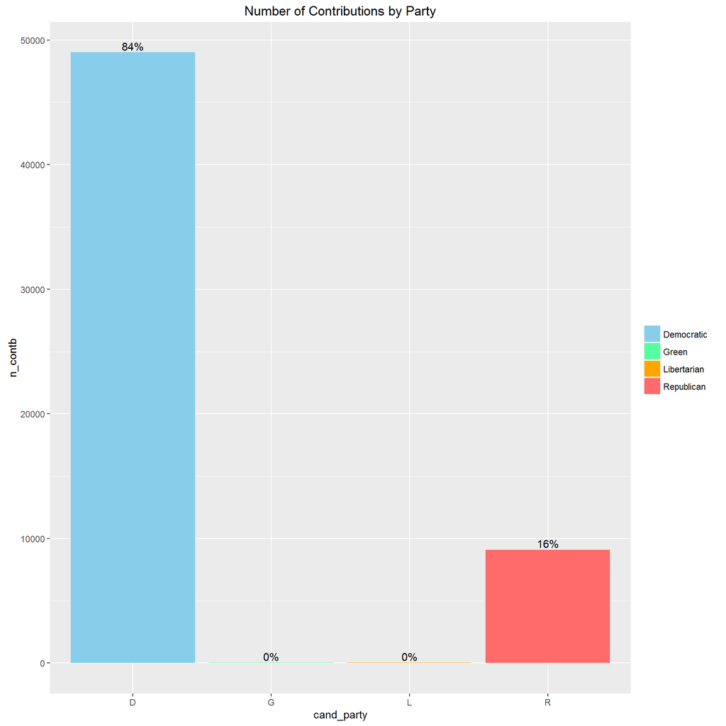

- Republicans got `39%` of contribution amount by just `16%` of contributions.
- Republicans contribution is distributed among many candidates.
- Democrats got `61%` of contribution amount by `84%` of contributions.

## Correlation between Median Contribution Amount and Median Household Income

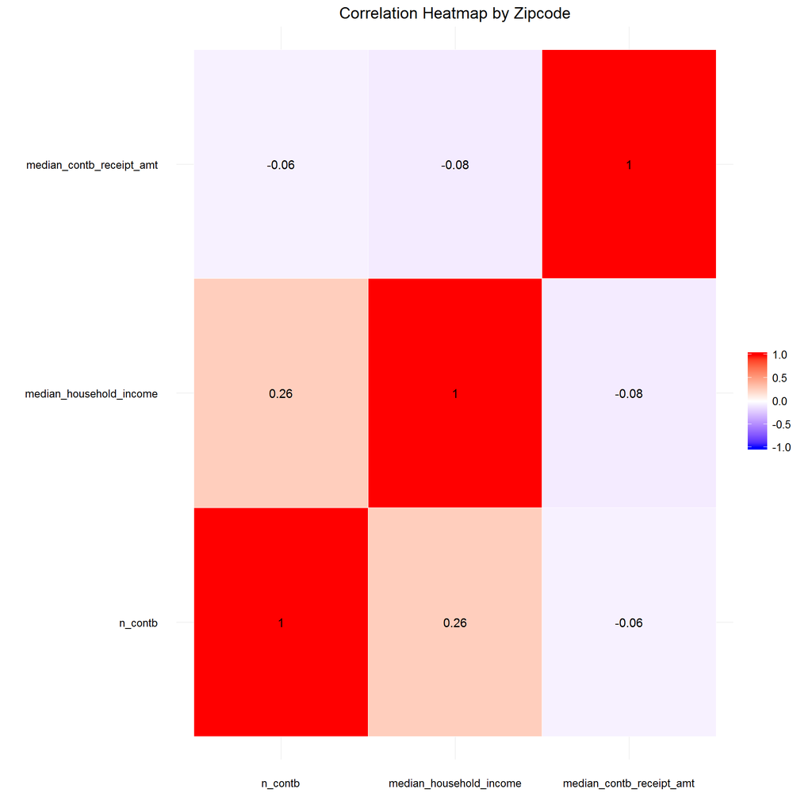

- Median Household income and number of contributions (`n_contb`) are somewhat related.
- Median contribution amount is not related to number of contribution or median household income.

## Correlation between Median Contribution Amount and Median Household Income by Party

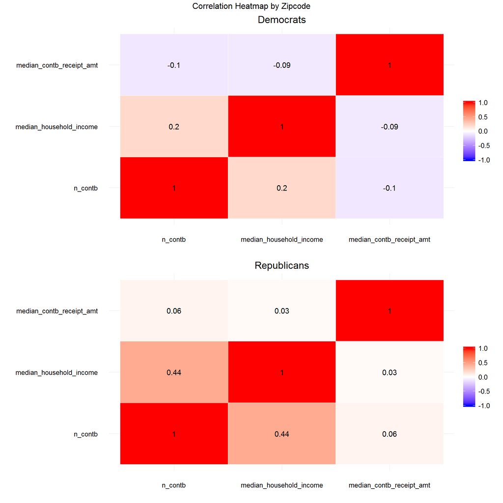

- Median Household income is related number of contributions and more in case of Republican contributions.
- Again, median contribution amount has no relation with number of contributions or median household income. However, its negative in case of Democrats and positive in case of Republican. Which could mean that, places with higher median household income contributed to Republicans more than Democrats and places with lower median household income contributed to Democrats more.

## Correlation between Median Contribution Amount and Median Household Income by Candidates

- Since there are too many candidates, first we find main candidates.
- Main Candidates: Top 5 Candidates by proportion of contribution amount, and top 5 candidates by number of contributions.

Top 5 by proportion of total contribution amount

| cand_nm_last | prop_contb_amt |
| --- | --- |
| Clinton | 0.448 |
| Sanders | 0.155 |
| Bush | 0.124 |
| Rubio | 0.071 |
| Cruz | 0.041 |
| Kasich | 0.041 |

Top 5 by proportion of number contributions

| cand_nm_last | prop_n_contb |
| --- | --- |
| Sanders | 0.541 |
| Clinton | 0.300 |
| Cruz | 0.058 |
| Carson | 0.030 |
| Rubio | 0.020 |

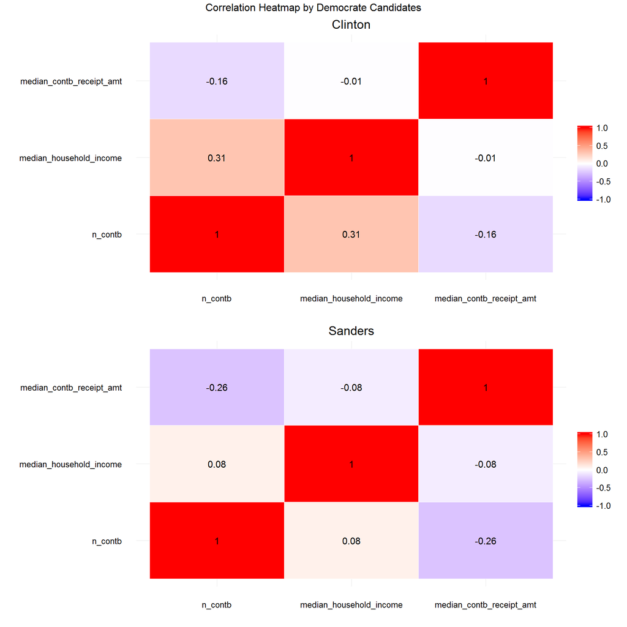

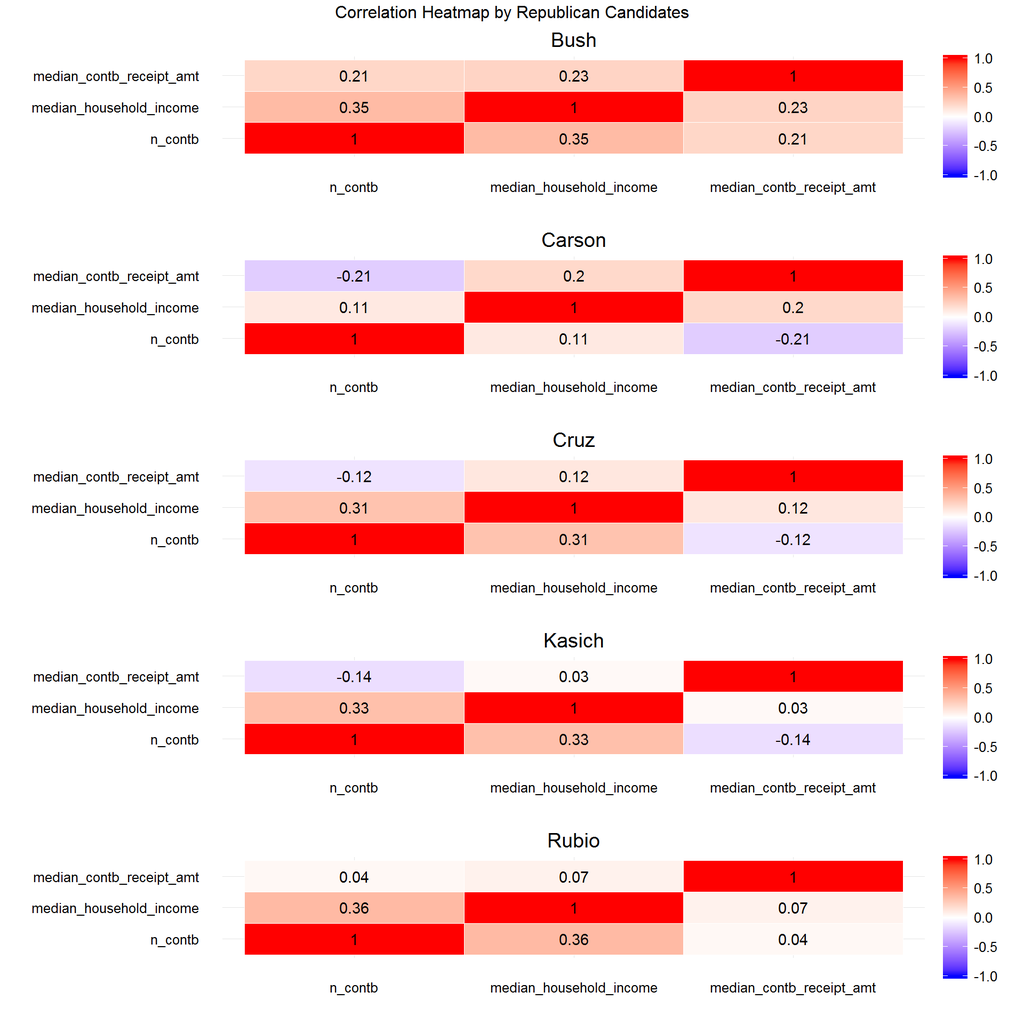

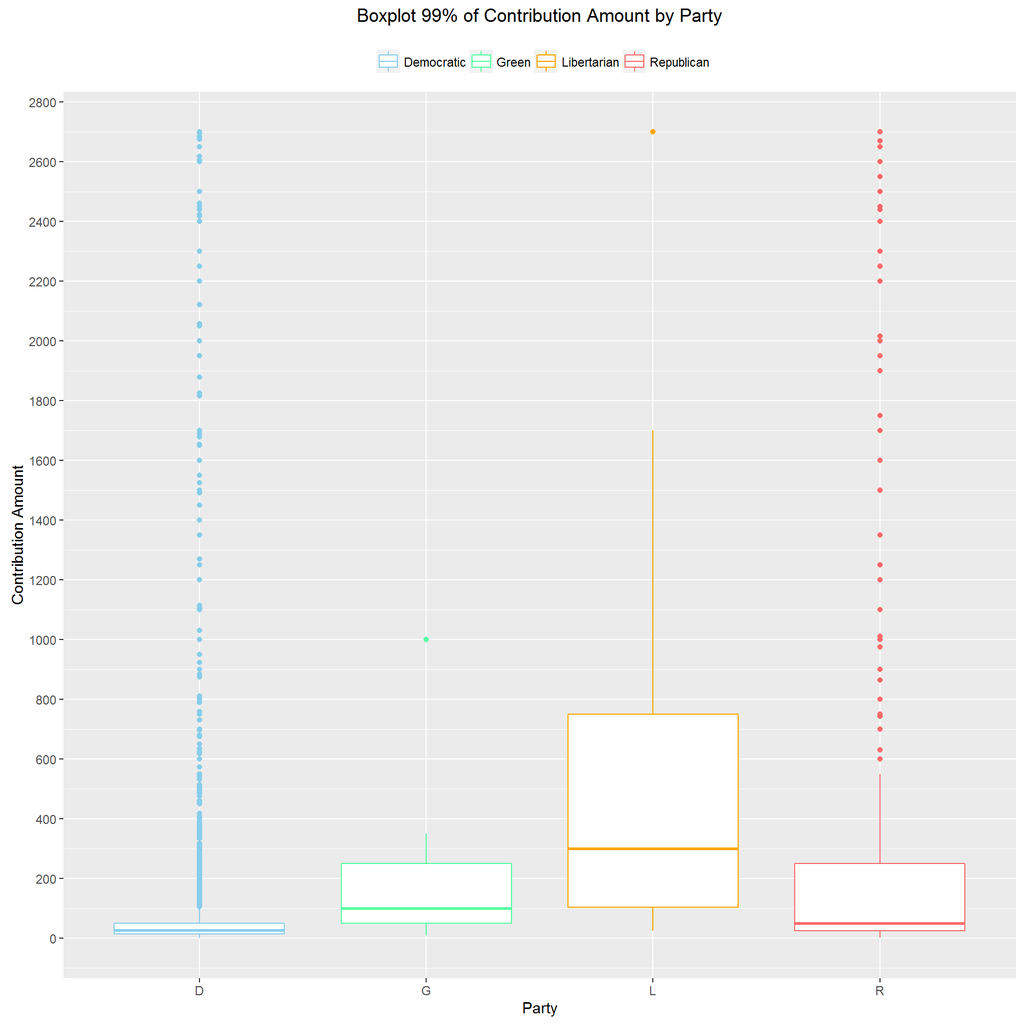

- Democrats median contribution amount is much lower than rest.

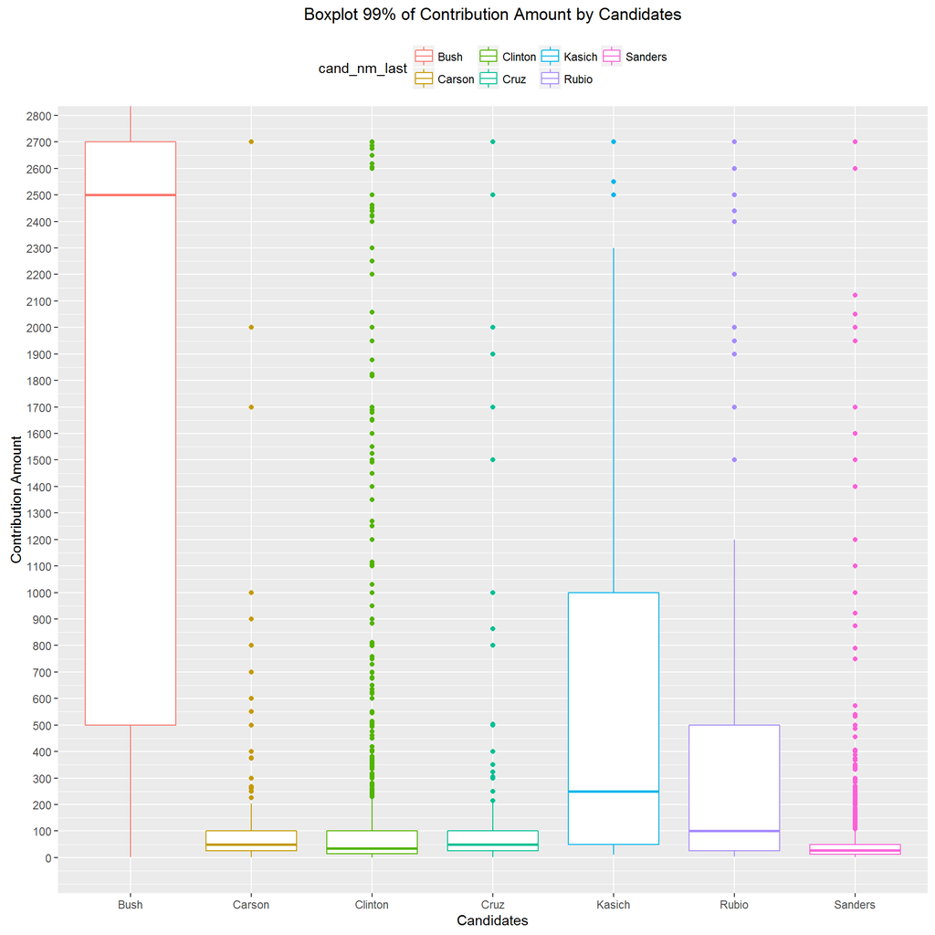

- Clinton’s median contribution amount is higher than Sander’s. However Sander got more contributions.

# Bivariate Analysis

### Talk about some of the relationships you observed in this part of the investigation. How did the feature(s) of interest vary with other features in the dataset?

- There is positive correlation (`0.26`) between median household income and number of contributions, which more apparent in Republican contribution (`0.44`). This implies number of contributions increases as median household income increases.
- In candidate wise correlation heatmap, Sanders has very low correlation between median household income and number of contributions (`0.08`). However, he has higher negative correlation (`-0.26`) correlation between median contribution amount and number of contributions, implies he got big number of small amount of contributions from low median household income places.
- Clinton and most of Republican have higher correlation between median household income and number of contributions.
- Party wise Scatter plot seems to suggest that Democrats for more contribution from lower median household income places. Also, number contributions for Democrats is higher for low median household income places.
- Sanders have high number of contributions from low median household income areas.

### What was the strongest relationship you found?

- Correlation between median household income and number of contribution for Republicans is higher than Democrats, that is areas where median household income is higher Republicans got more number of contributions.

# Multivariate Plots Section

## Scatter Plots

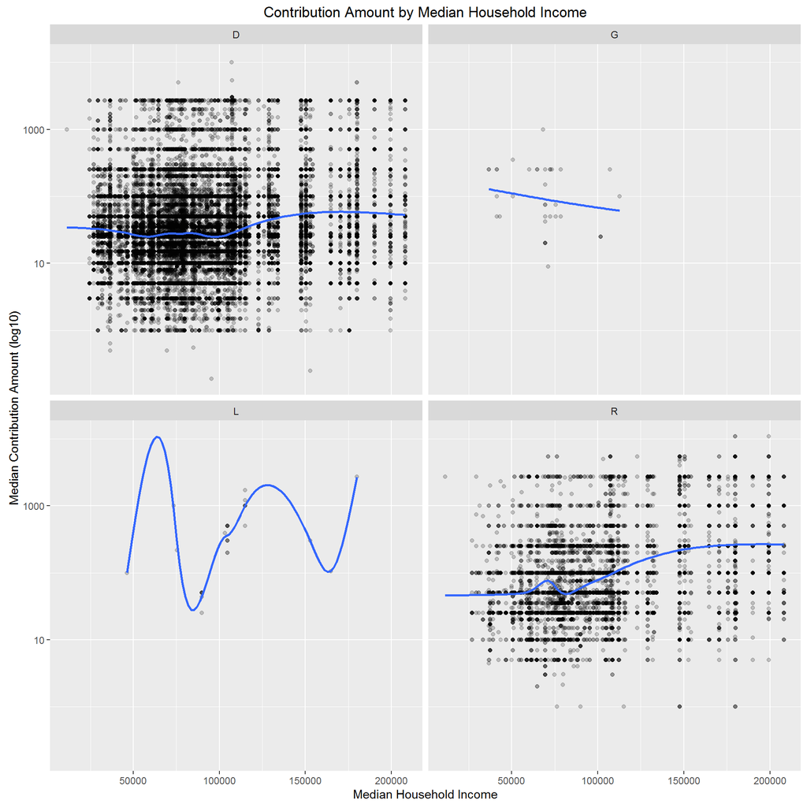

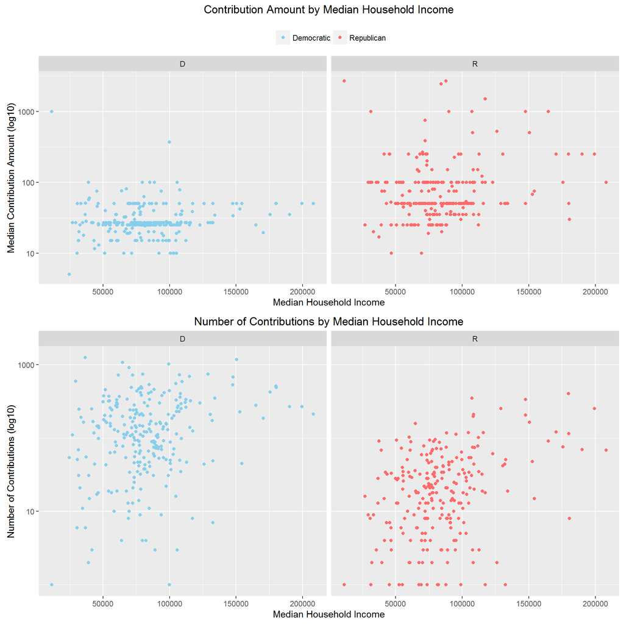

- There are many Democrats contributions from low median household income places, most of them are contributed to Sanders.
- Republicans get more or similar number of contributions as median household income increases.
- Democrats get more numer of contributions at lower median household income.
- Median contribution amount is lower for Democrats at every median household income level.

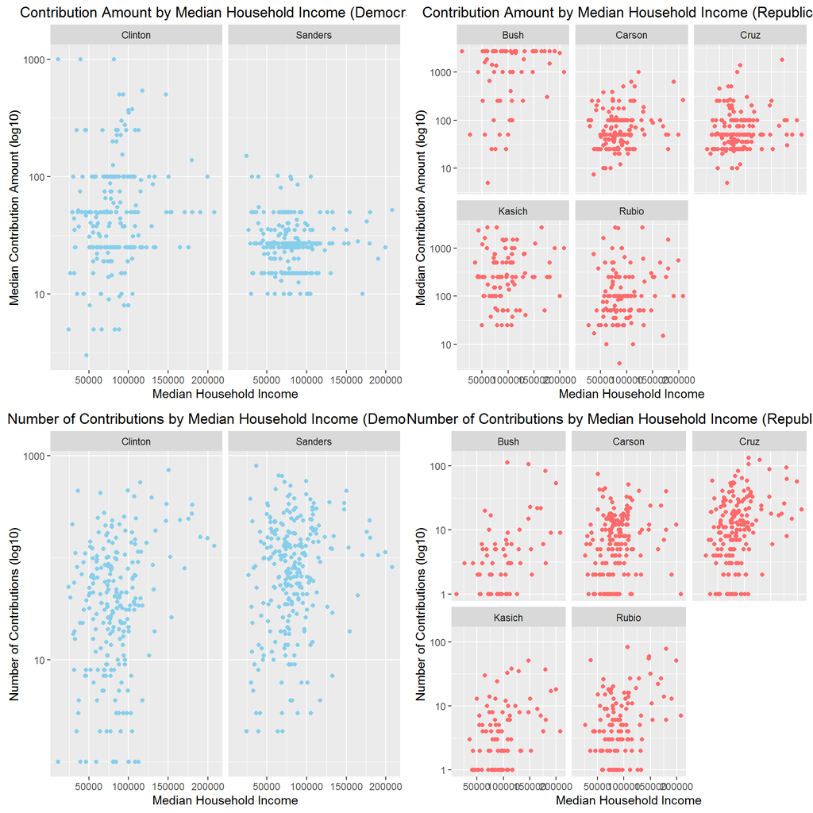

## Contribution over time

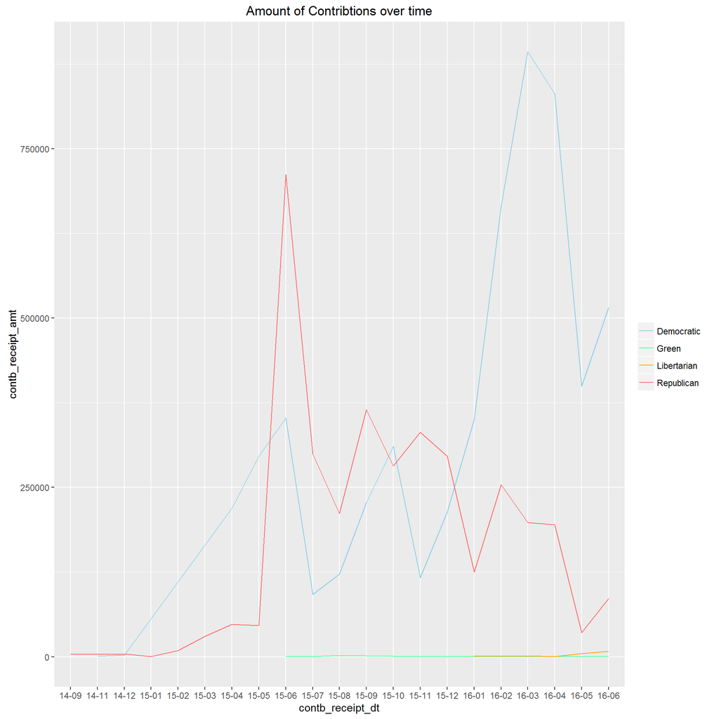

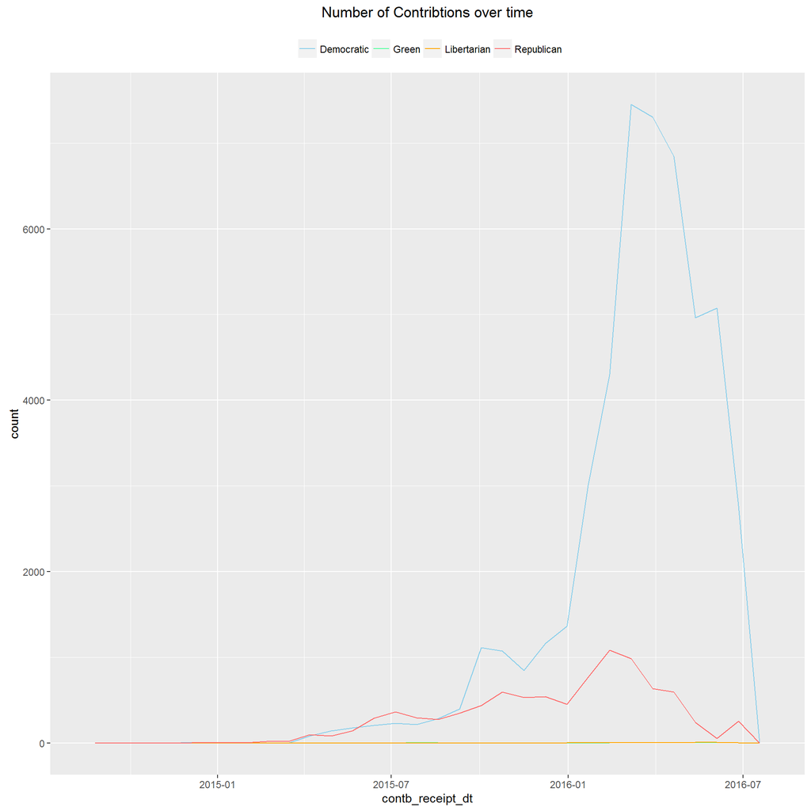

## Median Contribution Amount by Party and Candidates

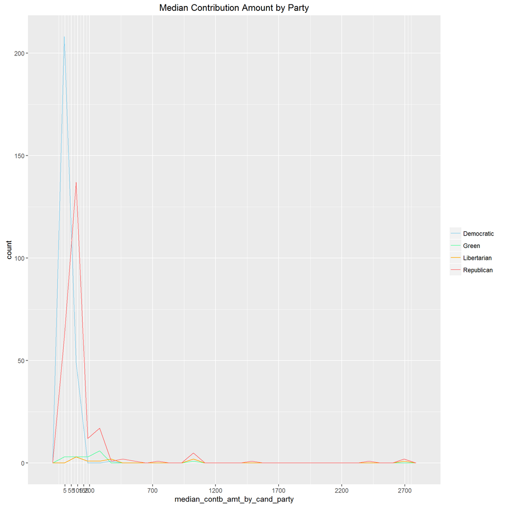

- For higher contribution amount, Democrats median contribution amount is lower than Republican’s

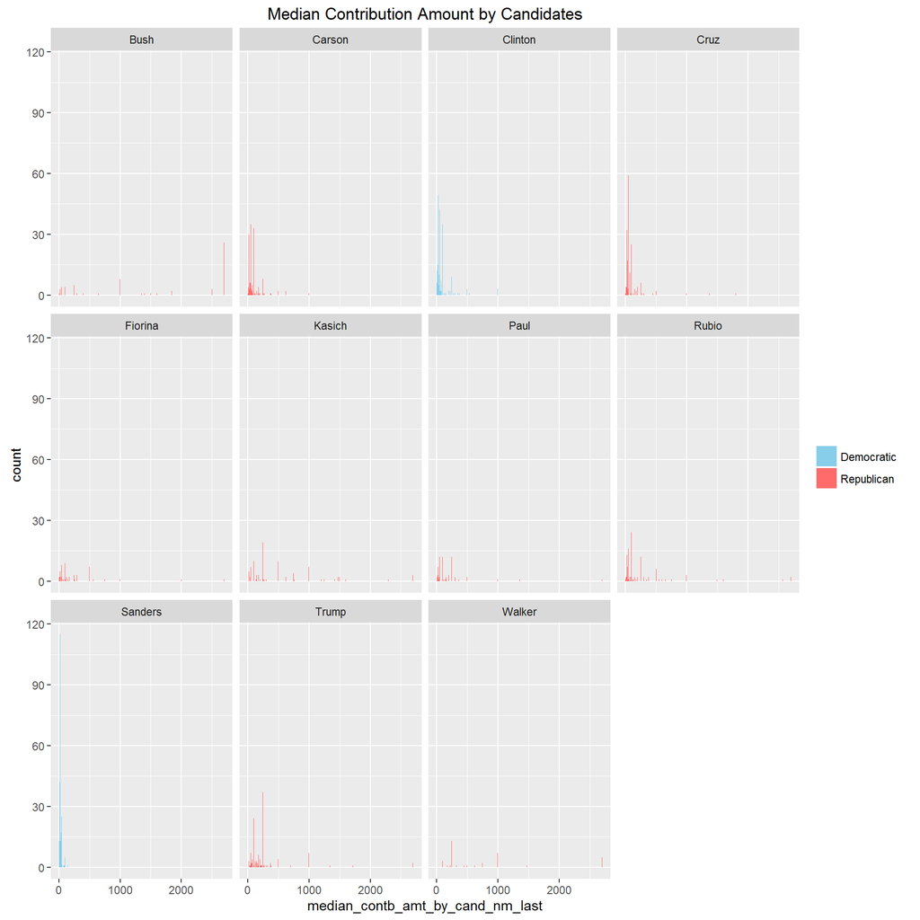

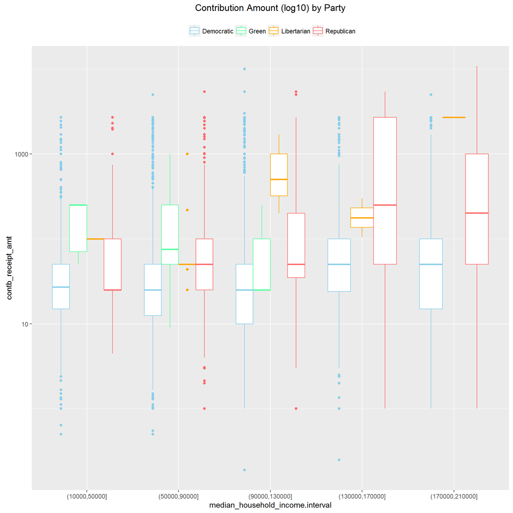

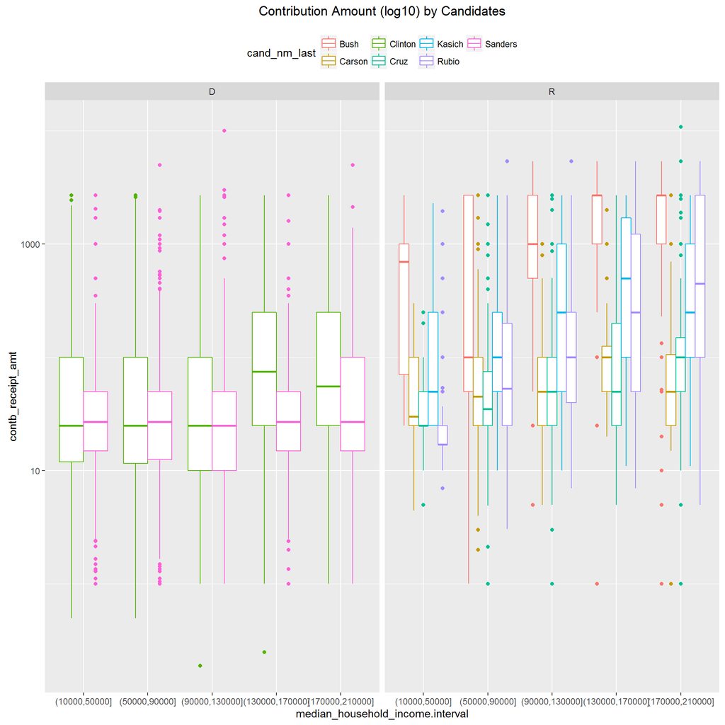

- Most of the Bush’s contribution came from higher income areas.
- Sanders got many small amount of contributions from lower and middle income areas.
- Clinton got contributions from every income area, she got relatively large amount of contributions.

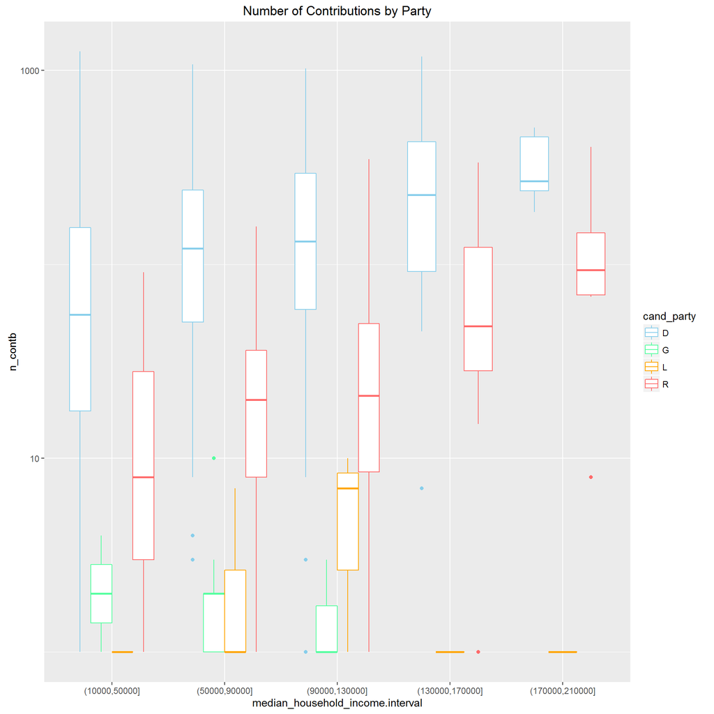

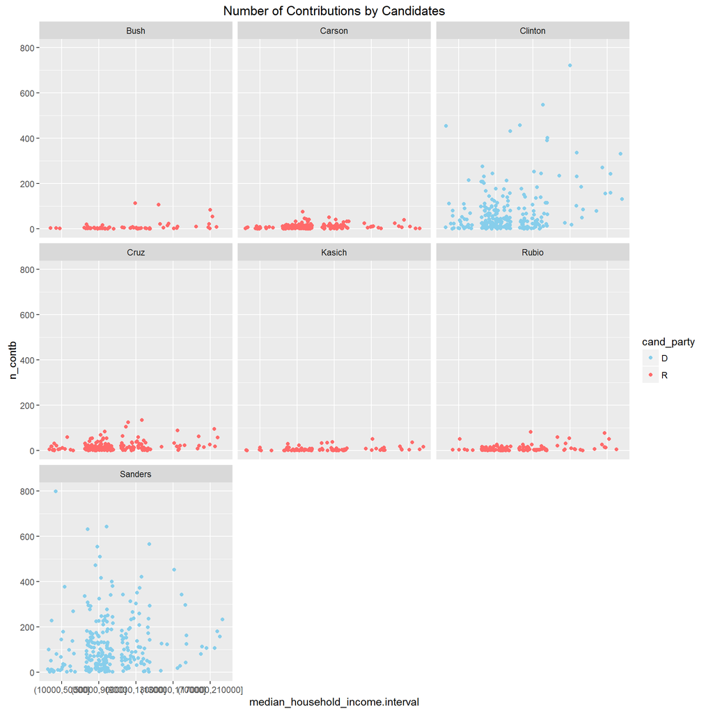

- Sanders got much more number of contributions from low and middle income areas then Clinton.

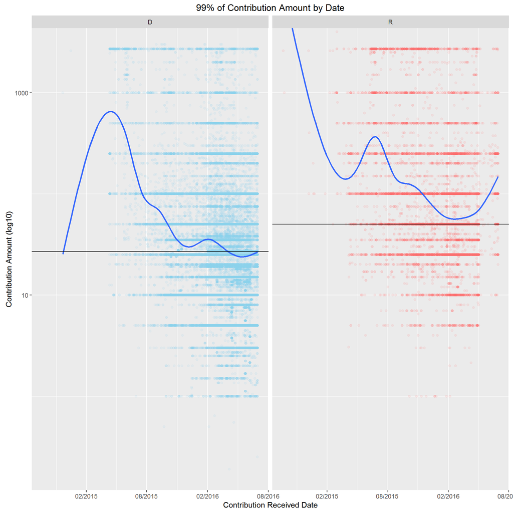

- Republican contribution increases at the end of the period.
- Democrats contribution keeps going down and it went below median line at the end of the period.

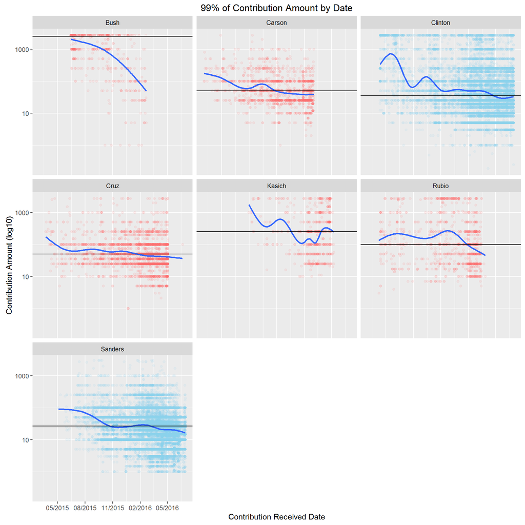

- All contributions decline over period of time. However, Bush is very steep.
- Clinton started getting very early and stayed at median line till end of the period.
- Sanders got more number of contributions in the end but amount went below median line.

# Multivariate Analysis

### Were there any interesting or surprising interactions between features?

- That Sanders was more popular in low and middle income areas, still his contribution amount was significantly less than Clinton.

### OPTIONAL: Did you create any models with your dataset? Discuss the strengths and limitations of your model.

# Final Plots and Summary

### Plot One

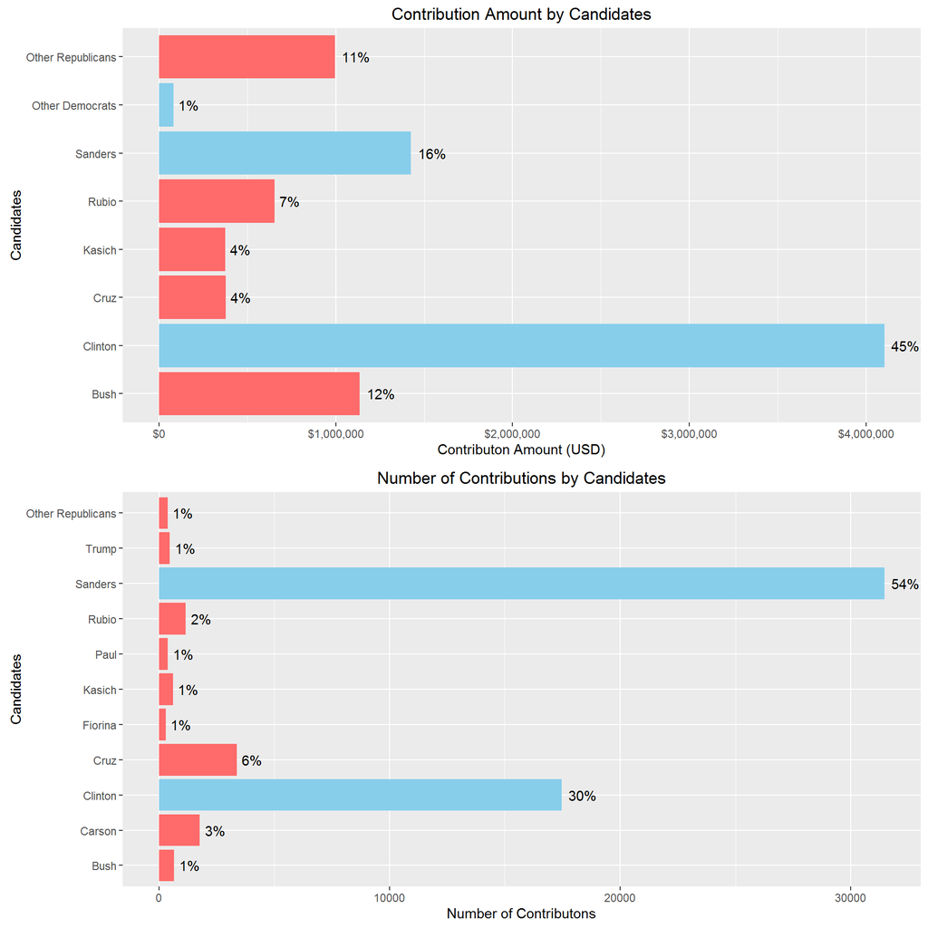

### Description One

- Amount of contribution and number of contributions per candidate, shows that Democrats got most of the contribution and with Democrats Sanders got most number of contributions while Clinton got most amount.

### Plot Two

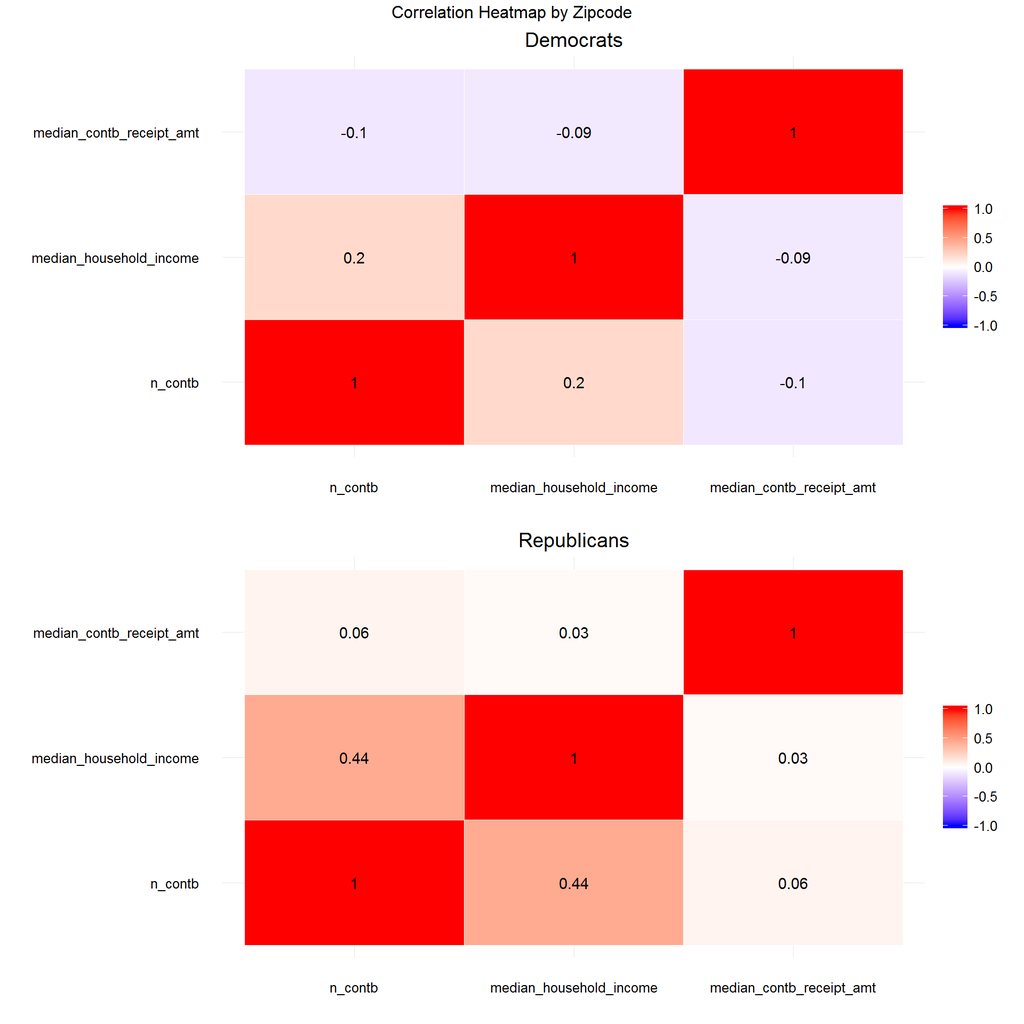

### Description Two

- Plot shows correlation between median contribution receipt amount, median household income and number of contributions by Democratic and Republican parties.
- Here, for each zipcode median household income, median contribution amount and number of contributions are used.
- This plot shows that Republicans have higher correlation between median household income and number of contributions.
- Since correlation is lower (`0.44`) this is not strong indication, but relatively it could mean Republicans received more number of contribution from the higher median household income areas.

### Plot Three

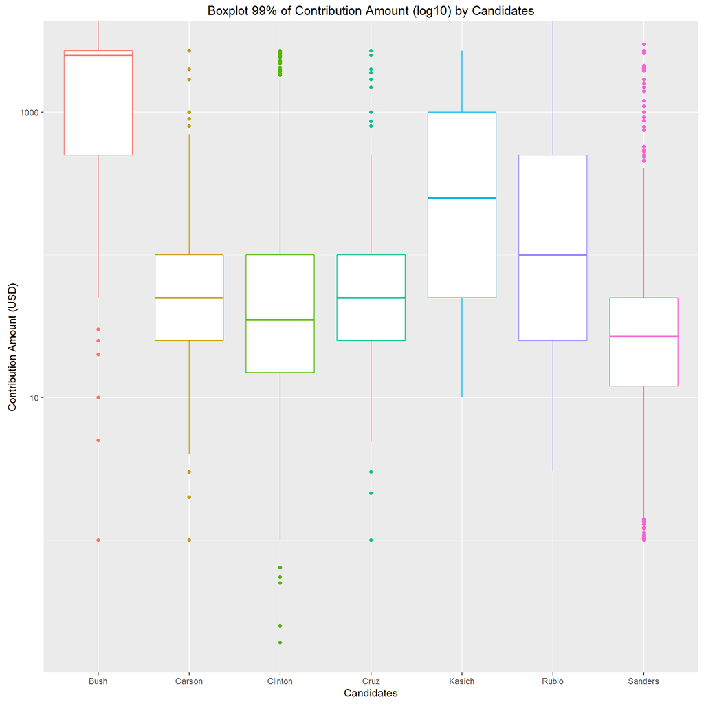

### Description Three

- This plot gives some idea about size of most contribution amount to a candidates.
- Bush received about `12%` of total contribution amount, his median contribution amount is much higher (`2500`), implies he received small number of higher amount contributions.
- Sanders median contribution amount is lowest (`27`), with `90%` contributions under `100`.
- Clinton has higher median contribution amount (`35`) with `90%` contributions under `500`.
- Contribution amount is much distributed in the Republican candidates, they received `39%` of contribution amount but no single candidate got more than `12%`.
- For Democrats contribution amount is between Clinton and Sanders only.
- Interesting fact is that, Sanders received `54%` of contributions which is way higher than any candidate, second on Clinton with `30%`.

Contribution Summary

| Name | Party | Contribution Amount | Number of Contributions | 0% | 25% | 50% | 90% | 100% | Avg Contribution Amount | % of Total Contribution Amount | % of Total Number of Contributions |
| --- | --- | --- | --- | --- | --- | --- | --- | --- | --- | --- | --- |
| All | All | 9165408.79 | 58172 | 0.19 | 15.0 | 27.000 | 250.0 | 10800 | 157.56 | 100% | 100% |
| All Democrats | D | 5610013.32 | 49006 | 0.19 | 13.5 | 27.000 | 125.9 | 10000 | 114.48 | 61% | 84% |
| All Republicans | R | 3533283.92 | 9098 | 1.00 | 25.0 | 50.000 | 1000.0 | 10800 | 388.36 | 39% | 16% |
| Clinton | D | 4103054.61 | 17461 | 0.19 | 15.0 | 35.000 | 500.0 | 2700 | 234.98 | 45% | 30% |
| Sanders | D | 1424724.71 | 31463 | 1.00 | 12.0 | 27.000 | 100.0 | 10000 | 45.28 | 16% | 54% |
| Other Democrats<sup>1</sup> | D | 82234.00 | 82 | 5.00 | 100.0 | 300.000 | 2700.0 | 5400 | 1002.85 | 1% | 0% |
| Bush | R | 1135478.00 | 663 | 1.00 | 500.0 | 2500.000 | 2700.0 | 5400 | 1712.64 | 12% | 1% |
| Rubio | R | 653084.86 | 1163 | 3.05 | 25.0 | 100.000 | 2700.0 | 5400 | 561.55 | 7% | 2% |
| Cruz | R | 376529.49 | 3376 | 1.00 | 25.0 | 50.000 | 200.0 | 10800 | 111.53 | 4% | 6% |
| Kasich | R | 373978.00 | 610 | 10.00 | 50.0 | 250.000 | 2700.0 | 2700 | 613.08 | 4% | 1% |
| Other Republicans<sup>2</sup> | R | 994213.57 | 3286 | 1.00 | 25.0 | 64.625 | 525.0 | 10800 | 302.56 | 11% | 6% |
| Johnson | L | 16330.55 | 31 | 25.00 | 102.4 | 300.000 | 1000.0 | 2700 | 526.79 | 0% | 0% |
| Stein | G | 5781.00 | 37 | 9.00 | 50.0 | 100.000 | 250.0 | 1000 | 156.24 | 0% | 0% |

- <sup>1</sup> Combined Democrate candidates who have received less than 4% of total contribution amount and less than 4% of total number of contributions.
- <sup>2</sup> Combined Republican candidates who have received less than 4% of total contribution amount and less than 4% of total number of contributions.

# Reflection

- Goal of analysis was to find some correlation between median household income and contribution amount to candidates and parties. However, we have not find any strong correlation, except Republican Party has `.44` correlation between median household income and number of contribution and even this number is not too strong.
- We try to analyze the distribution of contribution over time and by candidates and by parties, explained using visualization.
- Since, most of the contribution is between two candidates, Clinton and Sanders, there isn’t enough data to find some kind of trends.
- In future, we will like to add more features and see how those affect the amount and numbers of contributions. Some of the features could be
  - Education level by zip code in CT
    - [B15001: SEX BY AGE BY EDUCATIONAL ATTAINMENT FOR THE POPULATION 18 YEARS AND OVER, 2010-2014 American Community Survey 5-Year Estimates](http://factfinder.census.gov/faces/tableservices/jsf/pages/productview.xhtml?pid=ACS_14_5YR_B15001)
  - Distribution of Race and Ethnicity by zip code in CT.
    - [DP05: ACS DEMOGRAPHIC AND HOUSING ESTIMATES more information 2010-2014 American Community Survey 5-Year Estimates](http://factfinder.census.gov/bkmk/table/1.0/en/ACS/14_5YR/DP05/0100000US)